# R Notebook

```r
options(repos = c(CRAN = "https://cran.rstudio.com"))
```

```r
install.packages("readxl")
```

| Name | ID |
| --- | --- |
| Taif alrubeaan | 442202301 |
| Raghad Alboqami | 442200455 |
| Leena Alzahrani | 443200847 |
| Sarah Alghanim | 442201747 |

| The goal of collecting this dataset: |
| --- |
| our goal is to Identify whether the chances of of a heart attack occurrence is high or low for the patient |

## #classification and clustering goal:

Classification: We will classify target people into different groups based on appearance of muilty symptoms of Heart attack disease .This will allow us to predict the people who target to have heart attack based on certain factors .

Clustering: We will create a set of clusters for people who have similar symptoms. This will allow us to identify groups of people who are have the similar symptoms and target to have heart attack .

## We believe that by using these data mining tasks, we can build a model that can accurately predict the people target to have heart attack.

## 1 Problem

Recently, Cardiovascular diseases rate has been increased, which leads death globally. Early detection of the symptoms is important to prevent the disease from fully developing and reduce premature mortality. In our project, we will study and analyze patients’ data that will help us well in identifying symptoms that you don’t recognize as a sign of a heart disease and help many people to take precautions by predicting the possibility of having a Heart attack.

[output not shown]

## Attribute characteristics:

[output not shown]

Class label: -target of Heart Attack accurrance -not target of Heart Attack accurrance

| view dataset: |
| --- |

```r
install.packages("readxl")
library(readxl)
dataset <- read_excel("C:/Users/ragha/OneDrive/سطح المكتب/New folder/Heart Attack Data Set.xlsx")
View(dataset)
```

| Summary of dataset: |
| --- |

```r
nrow(dataset)
```

```
## [1] 303
```

```r
ncol(dataset)
```

```
## [1] 14
```

```r
summary(dataset$age)
```

```
##    Min. 1st Qu.  Median    Mean 3rd Qu.    Max.
##   29.00   47.50   55.00   54.37   61.00   77.00
```

```r
summary(dataset$cp)
```

```
##    Min. 1st Qu.  Median    Mean 3rd Qu.    Max.
##   0.000   0.000   1.000   0.967   2.000   3.000
```

```r
summary(dataset$trestbps)
```

```
##    Min. 1st Qu.  Median    Mean 3rd Qu.    Max.
##    94.0   120.0   130.0   131.6   140.0   200.0
```

```r
summary(dataset$chol)
```

```
##    Min. 1st Qu.  Median    Mean 3rd Qu.    Max.
##   126.0   211.0   240.0   246.3   274.5   564.0
```

```r
summary(dataset$oldpeak)
```

```
##    Min. 1st Qu.  Median    Mean 3rd Qu.    Max.
##    0.00    0.00    0.80    1.04    1.60    6.20
```

```r
summary(dataset$thalach)
```

```
##    Min. 1st Qu.  Median    Mean 3rd Qu.    Max.
##    71.0   133.5   153.0   149.6   166.0   202.0
```

```r
summary(dataset$slope)
```

```
##    Min. 1st Qu.  Median    Mean 3rd Qu.    Max.
##   0.000   1.000   1.000   1.399   2.000   2.000
```

```r
summary(dataset$ca)
```

```
##    Min. 1st Qu.  Median    Mean 3rd Qu.    Max.
##  0.0000  0.0000  0.0000  0.7294  1.0000  4.0000
```

```r
summary(dataset$thal)
```

```
##    Min. 1st Qu.  Median    Mean 3rd Qu.    Max.
##   0.000   2.000   2.000   2.314   3.000   3.000
```

| Missing values and Null values |
| --- |

```r
is.na(dataset)
```

[output not shown]

[output cut: 593 more lines]

```r
sum(is.na(dataset))
```

```
## [1] 0
```

The output is false and 0 this indicates that the element in our dataset is not missing

Graphs

Boxplot

check if balanced or not

`r boxplot(dataset$target, ylab= "the target boxplot", main= "Boxplot of target")`

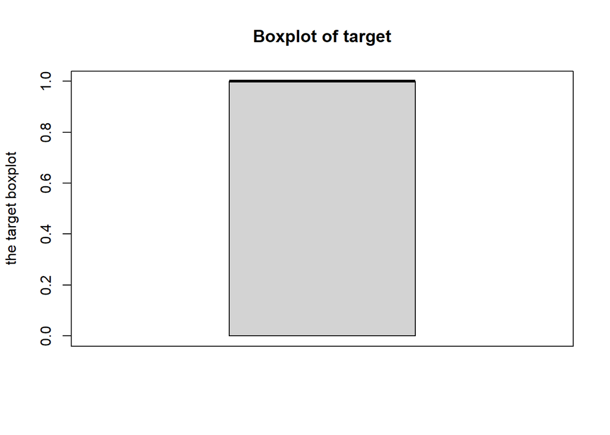

Since the median is not positioned in the middle of the box plot, it indicates that our dataset is imbalanced, and we need to make it balanced before classification.

`r install.packages("ggplot2")`

`r library(ggplot2)`

`## Warning: package 'ggplot2' was built under R version 4.3.2`

`r ggplot(data = dataset, aes(x = "", y = trestbps)) + geom_boxplot(fill = "lightgreen", color = "black") + labs( title = "Box Plot for resting blood pressure ", y = "trestbps", x = NULL # Remove x-axis label (since we only have one category) ) + theme_minimal()`

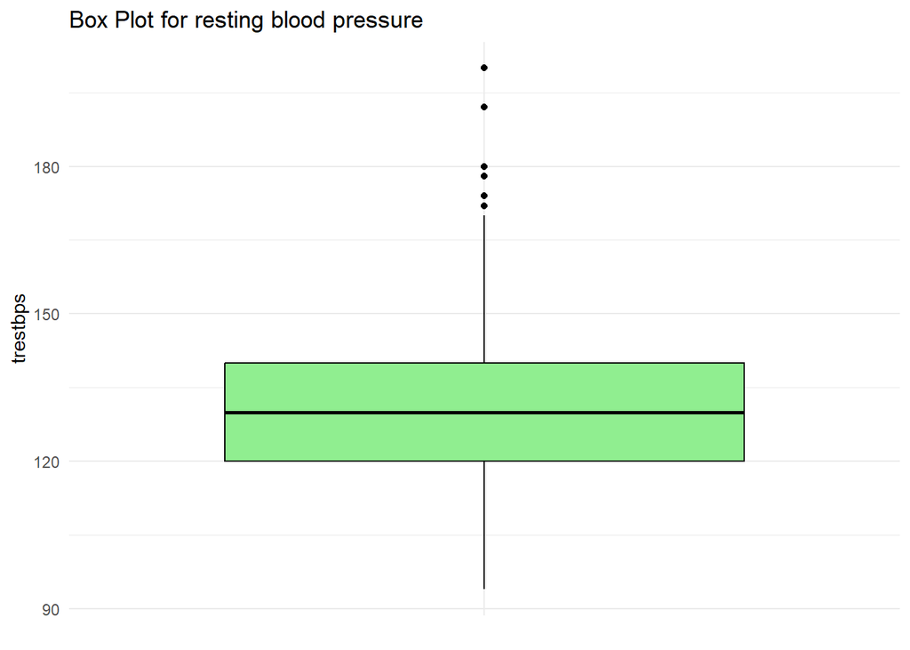

the Box Plot provides valuable insights into the distribution of resting blood pressure between 94- 200, highlighting the high blood pressure experienced by participants and the presence of potential outliers. In this example, any blood pressure below 94 or above 172 BPM would be considered an outlier.

`r ggplot(data = dataset, aes(x = "", y = thalach)) + geom_boxplot(fill = "lightpink", color = "black") + labs( title = "Box Plot for heart rate achieved ", y = "heart rate", x = NULL # Remove x-axis label (since we only have one category) ) + theme_minimal()`

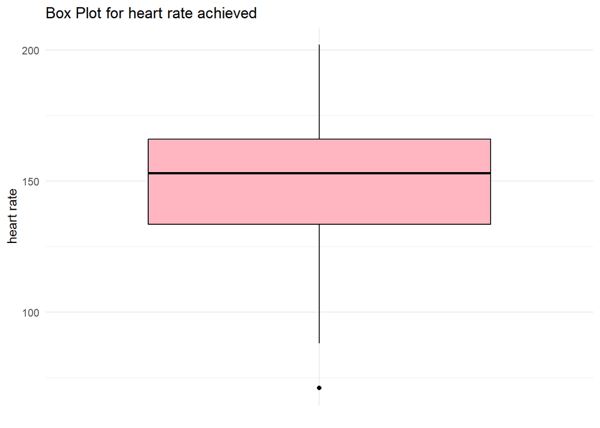

`r ggplot(data = dataset, aes(x = "", y = oldpeak)) + geom_boxplot(fill = "purple", color = "black") + labs( title = "Box Plot for ST depression", y = " ST depressione", x = NULL # Remove x-axis label (since we only have one category) ) + theme_minimal()`

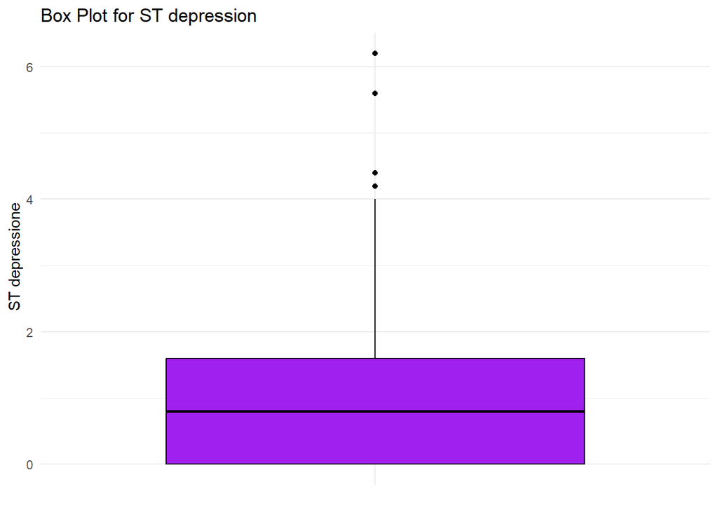

The St depression boxplot illustrates a lot of outliers above 4.20 that needs to be smoothed to remove the noise

`r ggplot(data = dataset, aes(x = "", y =chol)) + geom_boxplot(fill = "lightyellow", color = "black") + labs( title = "Box Plot for cholestero", y = "chol", x = NULL # Remove x-axis label (since we only have one category) ) + theme_minimal()`

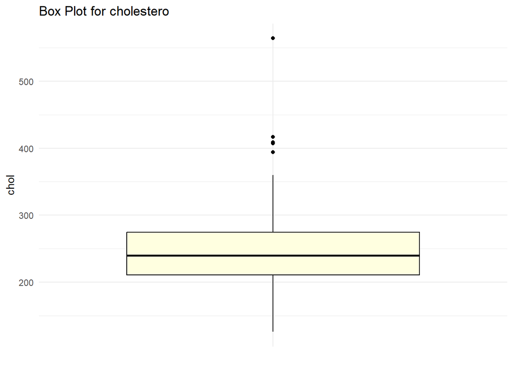

we can also detect summary of each attribute from the box plot , and we use box plot to detect the outlier.

Histogram

`r hist(dataset$chol)`

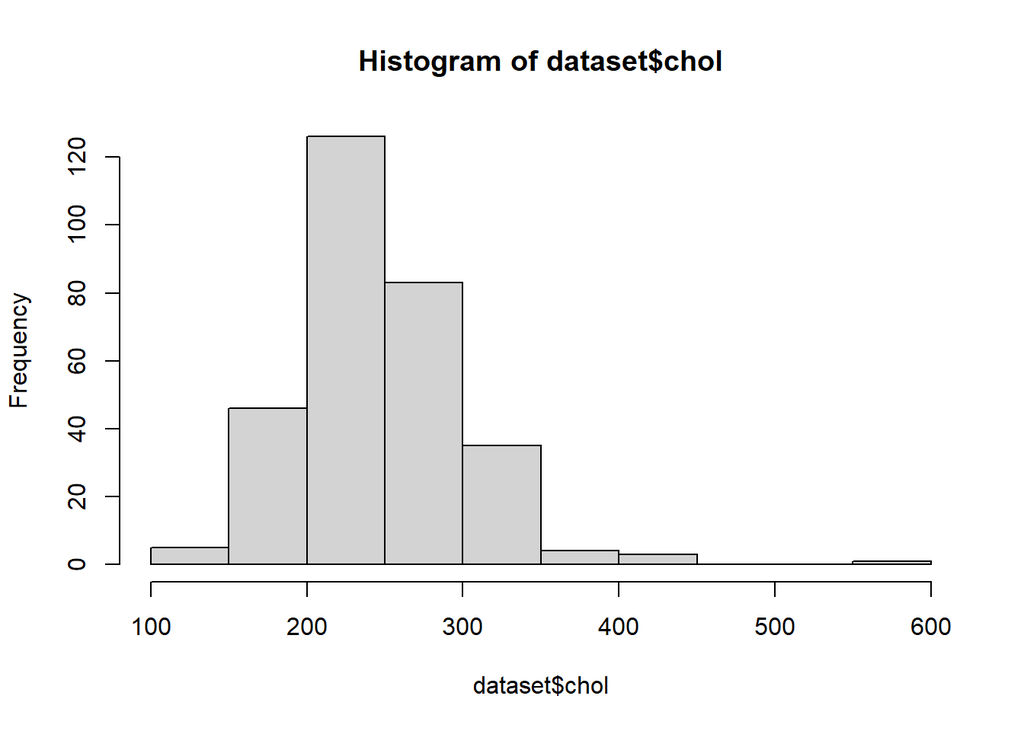

The graph represents the frequency of cholesterol in the data set. After observing the values, we concluded that most of the values fall in the range higher than the normal range, as the normal range falls between 125-200.

Scatter plot

`r library(ggplot2) gg <- ggplot(dataset, aes(x=chol, y=trestbps)) + geom_point(aes(col=target, size=oldpeak)) + labs(subtitle="trestbps Vs chol", y="trestbps", x="chol", title="Scatterplot", caption = "Source: midwest", bins = 30) plot(gg)`

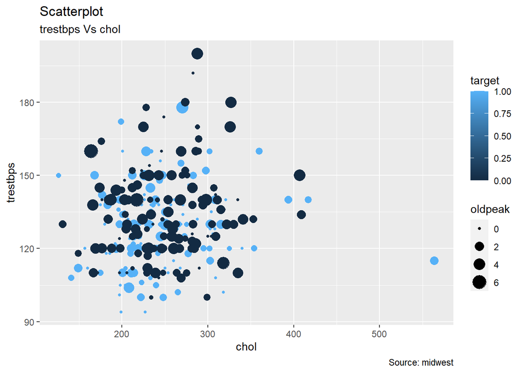

## outliers:

Detecting the outliers:

```r
  boxplot.stats (dataset$chol)$out
```

```
## [1] 417 564 394 407 409
```

```r
  boxplot.stats (dataset$trestbps)$out
```

```
## [1] 172 178 180 180 200 174 192 178 180
```

```r
  boxplot.stats (dataset$oldpeak)$out
```

```
## [1] 4.2 6.2 5.6 4.2 4.4
```

```r
  boxplot.stats (dataset$thalach)$out
```

```
## [1] 71
```

Removing the outliers:

```r
outliers <- boxplot (dataset$chol, plot=FALSE) $out
 dataset <- dataset [-which(dataset$chol %in% outliers),]
 boxplot.stats (dataset$chol) $out
```

```
## numeric(0)
```

```r
 outliers <- boxplot (dataset$trestbps, plot=FALSE) $out
 dataset <- dataset [-which(dataset$trestbps %in% outliers),]
 boxplot.stats (dataset$trestbps)$out
```

```
## numeric(0)
```

```r
 outliers <- boxplot (dataset$oldpeak, plot=FALSE) $out
 dataset <- dataset [-which(dataset$oldpeak %in% outliers),]
 boxplot.stats (dataset$oldpeak)$out
```

```
## numeric(0)
```

```r
 outliers <- boxplot (dataset$thalach, plot=FALSE) $out
 dataset <- dataset [-which(dataset$thalach %in% outliers),]
 boxplot.stats (dataset$thalach)$out
```

```
## numeric(0)
```

Description: First, we identified all outliers in the numeric attributes. Second, we deleted the rows where we find the outliers to produce more accurate dataset that help us to get more accurate results later, finally we checked again to make sure all outliers have been deleted then delete the new outliers that occurred because of the IQR change after deleting the rows in the second step.

| Attribute | Number of Outliers |
| --- | --- |
| chol | 5 |
| trestbps | 9 |
| oldpeak | 5 |
| thalach | 1 |

| Transformation and Normalization |
| --- |

Normalization:

```r
normalize <- function(x) {
  return((x - min(x)) / (max(x) - min(x)))
}

dataset$trestbps <- normalize(dataset$trestbps)
dataset$chol <- normalize(dataset$chol)
dataset$thalach <- normalize(dataset$thalach)
dataset$oldpeak <- normalize(dataset$oldpeak)
dataset$cp <- normalize(dataset$cp)
dataset$oldpeak <- normalize(dataset$oldpeak)
dataset$slope <- normalize(dataset$slope)
dataset$thal <- normalize(dataset$thal)
```

In order to ensure comparability across individuals and eliminate biases resulting from differences in measurement units or scales, we have decided to normalize the following attributes: trestbps, chol, thalach, oldpeak, cp, oldpeak, slope,and thal.

Discretization:

• Correlation Analysis: We will find the correlation between each attribute and the class label (target). For the nominal data we will use chi-square and for the numeric data we will use correlation coefficient. This will help us to determine the most important and correlated attributes to the target.

```r
####Sex:

csex=chisq.test(dataset$sex , dataset$target)
print(csex)
```

```
##
##  Pearson's Chi-squared test with Yates' continuity correction
##
## data:  dataset$sex and dataset$target
## X-squared = 27.015, df = 1, p-value = 2.019e-07
```

```r
####Chest pain type (cp):

ccp=chisq.test(dataset$cp , dataset$target)
print(ccp)
```

```
##
##  Pearson's Chi-squared test
##
## data:  dataset$cp and dataset$target
## X-squared = 75.192, df = 3, p-value = 3.296e-16
```

```r
####Fasting blood sugar (fbs):

cfbs=chisq.test(dataset$fbs , dataset$target)
print(cfbs)
```

```
##
##  Pearson's Chi-squared test with Yates' continuity correction
##
## data:  dataset$fbs and dataset$target
## X-squared = 0.094456, df = 1, p-value = 0.7586
```

```r
####Resting electrocardiographic result (restecg):

crestecg=chisq.test(dataset$restecg , dataset$target)
print(crestecg)
```

```
##
##  Pearson's Chi-squared test
##
## data:  dataset$restecg and dataset$target
## X-squared = 9.4074, df = 2, p-value = 0.009062
```

```r
####Exercise induced anginal (exang):

cexang=chisq.test(dataset$exang , dataset$target)
print(cexang)
```

```
##
##  Pearson's Chi-squared test with Yates' continuity correction
##
## data:  dataset$exang and dataset$target
## X-squared = 51.335, df = 1, p-value = 7.786e-13
```

```r
####The slope of the peak exercise ST segment (slope):

cslope=chisq.test(dataset$slope , dataset$target)
print(cslope)
```

```
##
##  Pearson's Chi-squared test
##
## data:  dataset$slope and dataset$target
## X-squared = 42.008, df = 2, p-value = 7.552e-10
```

```r
####Number of major vessels (ca):

cca=chisq.test(dataset$ca , dataset$target)
print(cca)
```

```
##
##  Pearson's Chi-squared test
##
## data:  dataset$ca and dataset$target
## X-squared = 69.764, df = 4, p-value = 2.546e-14
```

```r
####A blood disorder (thal):

cthal=chisq.test(dataset$thal , dataset$target)
print(cthal)
```

```
##
##  Pearson's Chi-squared test
##
## data:  dataset$thal and dataset$target
## X-squared = 82.619, df = 3, p-value < 2.2e-16
```

```r
####Age: The age attribute after discretization.

cage= chisq.test(dataset$age, dataset$target)
print(cage)
```

```
##
##  Pearson's Chi-squared test
##
## data:  dataset$age and dataset$target
## X-squared = 15.051, df = 3, p-value = 0.001774
```

```r
####Resting blood pressure (trestbps)

ctrestbps=chisq.test(dataset$trestbps ,dataset$target)
print(ctrestbps)
```

```
##
##  Pearson's Chi-squared test
##
## data:  dataset$trestbps and dataset$target
## X-squared = 40.415, df = 41, p-value = 0.4965
```

[output not shown]

| ###Correlation coefficient for numeric data: |
| --- |

```r
####Serum cholestoral (chol):

cchol=cor(dataset$chol ,dataset$target)
print(cchol)
```

```
## [1] -0.1097638
```

```r
####Maximum heart rate achieved (thalach):

cthalach=cor(dataset$thalach ,dataset$target)
print(cthalach)
```

```
## [1] 0.4243806
```

```r
####ST depression indicated by exercise relative to rest (oldpeak):

coldpeak=cor(dataset$oldpeak ,dataset$target)
print(coldpeak)
```

```
## [1] -0.4357483
```

Description: The highest correlation coefficient value is ST depression indicated by exercise relative to rest (oldpeak) which is negatively correlated (-0.4357483) with the target. Then, the value of maximum heart rate achieved (thalach) which is positively correlated (0.4243806) with the target. Lastly, the value of Serum cholestoral (chol) which is negatively correlated (-0.1097638) with the target.

From the previous results we decided to delete the Fasting blood sugar (fbs) since it is independent from the class label (target) which means that fasting blood sugar (fbs) doesn’t affect our class label (target).

```r
dataset <- dataset[, -which(names(dataset) == "fbs")]
head(dataset)
```

| age | sex | cp | trestbps | chol | restecg | thalach | exang | oldpeak | slope | ca | thal | target |
| --- | --- | --- | --- | --- | --- | --- | --- | --- | --- | --- | --- | --- |
| (59,69] | 1 | 1.0000000 | 0.6710526 | 0.4572650 | 0 | 0.5438596 | 0 | 0.575 | 0.0 | 0 | 0.3333333 | 1 |
| (29,39] | 1 | 0.6666667 | 0.4736842 | 0.5299145 | 1 | 0.8684211 | 0 | 0.875 | 0.0 | 0 | 0.6666667 | 1 |
| (39,49] | 0 | 0.3333333 | 0.4736842 | 0.3333333 | 0 | 0.7368421 | 0 | 0.350 | 1.0 | 0 | 0.6666667 | 1 |
| (49,59] | 1 | 0.3333333 | 0.3421053 | 0.4700855 | 1 | 0.7894737 | 0 | 0.200 | 1.0 | 0 | 0.6666667 | 1 |
| (49,59] | 0 | 0.0000000 | 0.3421053 | 0.9743590 | 1 | 0.6578947 | 1 | 0.150 | 1.0 | 0 | 0.6666667 | 1 |
| (49,59] | 1 | 0.0000000 | 0.6052632 | 0.2820513 | 1 | 0.5263158 | 0 | 0.100 | 0.5 | 0 | 0.3333333 | 1 |

```r
ncol(dataset)
```

```
## [1] 13
```

```r
nrow(dataset)
```

```
## [1] 284
```

Description: After printing a sample from our new data set we notice that the attribute decrease from 14 to 13 since we remove Fasting blood sugar (fbs) and the rows remain the same.

```r
print(data)
```

[output not shown]

[output cut: 128 more lines]

[output not shown]

we apply chi-square and correlation coefficient to know the attribute that affect our class label in preprocessing ,then started work in classification. Classification: is a supervised learning technique where a model is trained on a labeled dataset, meaning the dataset has already been tagged or classified with the correct class labels. while we try to increase the accuracy, we try different way one of this way was add attribute and remove attribute and we noticed that the following attribute:slope , doesn’t affect accuracy adding them or removing them doesn’t change anything.

[output not shown]

## split the data in training and test data (75/25)

```r
set.seed(123)
data_split <- initial_split(dataset, prop = 0.75)
train_data <- training(data_split)
test_data <- testing(data_split)
```

## build decision tree for each partition and measure

```r
tree_1_ig <- rpart(as.factor(target) ~ ., data = train_data, method = "class", parms = list(split = "information"))

tree_1_gini <- rpart(target ~ ., data = train_data, method = "class", parms = list(split = "gini"))

tree_1_gr <- rpart(target ~ ., data = train_data, method = "class", parms = list(split = "anova"))
```

##plot the decision trees for each measure(IG)

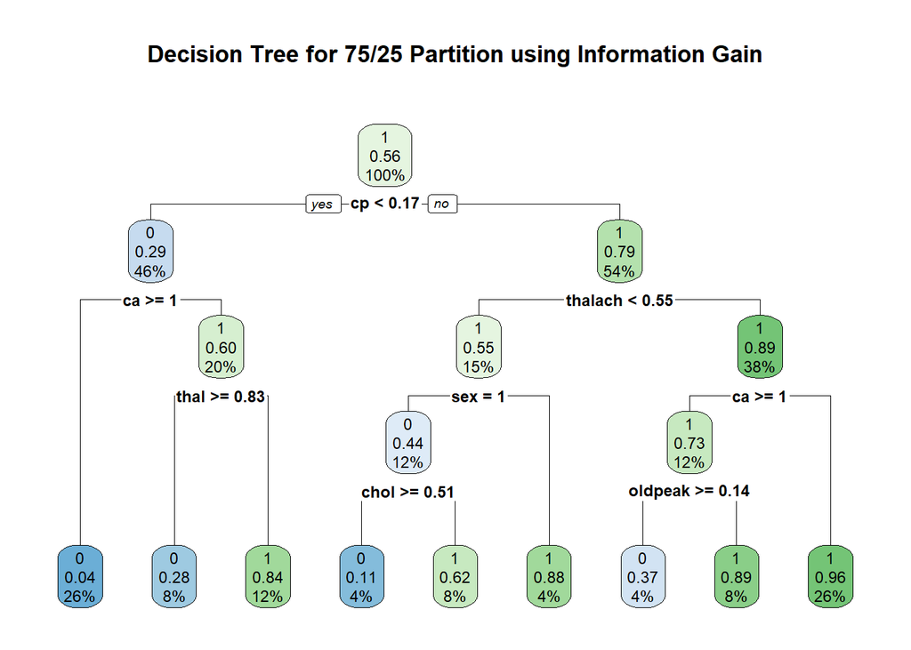

```r
rpart.plot(tree_1_ig, main = "Decision Tree for 75/25 Partition using Information Gain")
```

This s a decision tree diagram for a 75/25 partition using information gain.The result shows that Chest pain type (cp) had the highest information gain value so it was represented in first level (root).The tree contains 7 variables with 8 splits. Splits have occurred on the variables Cp, Ca ,thalach, thal,sex and chol and oldpeak.

```r
#predict the target on the test set
pred_1_ig <- predict(tree_1_ig, newdata = test_data, type = "class")

pred <- as.factor(pred_1_ig)
actual <- as.factor(test_data$target)

confusionMatrix(pred, actual)
```

```
## Confusion Matrix and Statistics
##
##           Reference
## Prediction  0  1
##          0 22  5
##          1  9 35
##
##                Accuracy : 0.8028
##                  95% CI : (0.6914, 0.8878)
##     No Information Rate : 0.5634
##     P-Value [Acc > NIR] : 1.967e-05
##
##                   Kappa : 0.5933
##
##  Mcnemar's Test P-Value : 0.4227
##
##             Sensitivity : 0.7097
##             Specificity : 0.8750
##          Pos Pred Value : 0.8148
##          Neg Pred Value : 0.7955
##              Prevalence : 0.4366
##          Detection Rate : 0.3099
##    Detection Prevalence : 0.3803
##       Balanced Accuracy : 0.7923
##
##        'Positive' Class : 0
##
```

```r
#create a confusion matrix
table(pred_1_ig, test_data$target)
```

```
##
## pred_1_ig  0  1
##         0 22  5
##         1  9 35
```

```r
#calculate the overall accuracy
mean(pred_1_ig ==  test_data$target)
```

```
## [1] 0.8028169
```

```r
# Manually calculate precision
precision <- 22 / (22 + 5)

# Print precision
print(paste("Precision:", precision))
```

```
## [1] "Precision: 0.814814814814815"
```

| Evaluation Method | Value |
| --- | --- |
| Accuracy | 80% |
| Precision | 81.4% |
| Sensitivity | 70.9% |
| Specificity | 87.5% |

## plot the decision trees for each measure(Gini index)

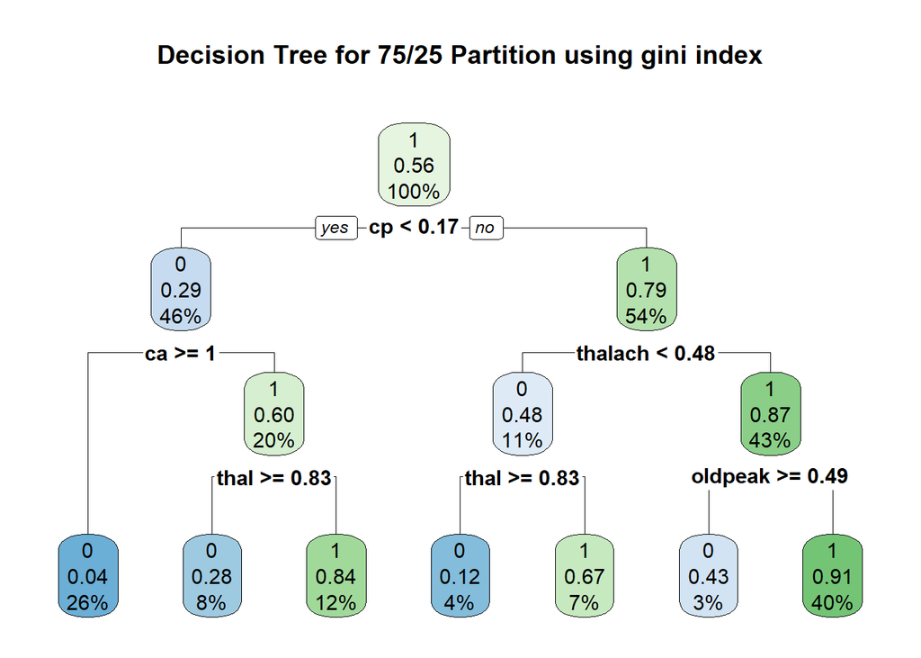

```r
rpart.plot(tree_1_gini, main = "Decision Tree for 75/25 Partition using gini index")
```

This s a decision tree diagram for a 75/25 partition using Gini index .The result shows that Chest pain type (cp) had the highest ΔGini value so it was represented in first level (root).The tree contains 5 variables with 6 splits. Splits have occurred on the variables Cp, Ca ,thalach, thal, and oldpeak.

```r
#predict the target on the test set
tree_1_gini <- predict(tree_1_gini, newdata = test_data, type = "class")

#create a confusion matrix
table(tree_1_gini, test_data$target)
```

```
##
## tree_1_gini  0  1
##           0 24  4
##           1  7 36
```

```r
pred <- as.factor(tree_1_gini)
actual <- as.factor(test_data$target)

confusionMatrix(pred, actual)
```

```
## Confusion Matrix and Statistics
##
##           Reference
## Prediction  0  1
##          0 24  4
##          1  7 36
##
##                Accuracy : 0.8451
##                  95% CI : (0.7397, 0.92)
##     No Information Rate : 0.5634
##     P-Value [Acc > NIR] : 4.062e-07
##
##                   Kappa : 0.6816
##
##  Mcnemar's Test P-Value : 0.5465
##
##             Sensitivity : 0.7742
##             Specificity : 0.9000
##          Pos Pred Value : 0.8571
##          Neg Pred Value : 0.8372
##              Prevalence : 0.4366
##          Detection Rate : 0.3380
##    Detection Prevalence : 0.3944
##       Balanced Accuracy : 0.8371
##
##        'Positive' Class : 0
##
```

```r
#calculate the overall accuracy
mean(tree_1_gini ==  test_data$target)
```

```
## [1] 0.8450704
```

```r
# Manually calculate precision
precision <- 24 / (24 + 4)

# Print precision
print(paste("Precision:", precision))
```

```
## [1] "Precision: 0.857142857142857"
```

| Evaluation Method | Value |
| --- | --- |
| Accuracy | 84.5% |
| Precision | 85.7% |
| Sensitivity | 77.4% |
| Specificity | 90% |

## plot the decision trees for each measure(GINI ratio)

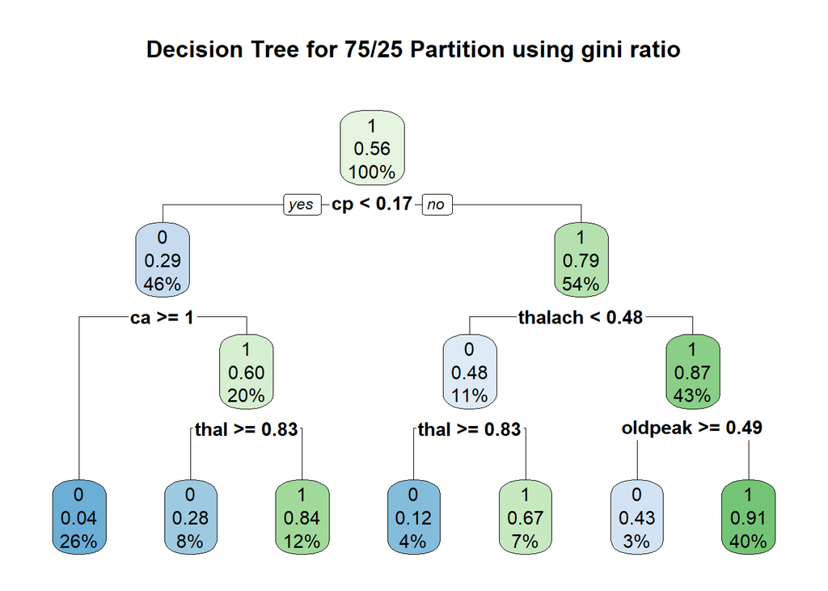

```r
rpart.plot(tree_1_gr, main = "Decision Tree for 75/25 Partition using gini ratio")
```

This s a decision tree diagram for a 75/25 partition using Gini ratio .The result shows that Chest pain type (cp) had the highest Gini ratio value so it was represented in first level (root).The tree contains 5 variables with 6 splits. Splits have occurred on the variables Cp, Ca ,thalach, thal,and oldpeak.

```r
#predict the target on the test set
tree_1_gr <- predict(tree_1_gr, newdata = test_data, type = "class")

#create a confusion matrix
table(tree_1_gr, test_data$target)
```

```
##
## tree_1_gr  0  1
##         0 24  4
##         1  7 36
```

```r
pred <- as.factor(tree_1_gr)
actual <- as.factor(test_data$target)

confusionMatrix(pred, actual)
```

```
## Confusion Matrix and Statistics
##
##           Reference
## Prediction  0  1
##          0 24  4
##          1  7 36
##
##                Accuracy : 0.8451
##                  95% CI : (0.7397, 0.92)
##     No Information Rate : 0.5634
##     P-Value [Acc > NIR] : 4.062e-07
##
##                   Kappa : 0.6816
##
##  Mcnemar's Test P-Value : 0.5465
##
##             Sensitivity : 0.7742
##             Specificity : 0.9000
##          Pos Pred Value : 0.8571
##          Neg Pred Value : 0.8372
##              Prevalence : 0.4366
##          Detection Rate : 0.3380
##    Detection Prevalence : 0.3944
##       Balanced Accuracy : 0.8371
##
##        'Positive' Class : 0
##
```

```r
#calculate the overall accuracy
mean(tree_1_gr ==  test_data$target)
```

```
## [1] 0.8450704
```

```r
# Manually calculate precision
precision <- 24 / (24 + 4)

# Print precision
print(paste("Precision:", precision))
```

```
## [1] "Precision: 0.857142857142857"
```

| Evaluation Method | Value |
| --- | --- |
| Accuracy | 84.5% |
| Precision | 85.7% |
| Sensitivity | 77.4% |
| Specificity | 90% |

## C4.5 algorithm (75/25)

```r
library(RWeka)
# load the package
library(RWeka)
# load data
# fit model
tree <- J48(as.factor(target) ~ ., data = train_data)
# summarize the fit
summary(tree)
```

```
##
## === Summary ===
##
## Correctly Classified Instances         189               92.1951 %
## Incorrectly Classified Instances        16                7.8049 %
## Kappa statistic                          0.8404
## Mean absolute error                      0.1357
## Root mean squared error                  0.2605
## Relative absolute error                 27.5426 %
## Root relative squared error             52.4848 %
## Total Number of Instances              205
##
## === Confusion Matrix ===
##
##    a   b   <-- classified as
##   79  11 |   a = 0
##    5 110 |   b = 1
```

```r
# make predictions
predictions <- predict(tree, test_data)
# summarize accuracy
table(predictions, test_data$target)
```

```
##
## predictions  0  1
##           0 22  8
##           1  9 32
```

```r
#calculate the overall accuracy
mean(predictions ==  test_data$target)
```

```
## [1] 0.7605634
```

```r
library(partykit)
```

```r
# load the package
library(ipred)
# fit model
tree <- Bagging (as.factor(target) ~ ., data = train_data)
summary(tree)
```

```
##
## === Summary ===
##
## Correctly Classified Instances         185               90.2439 %
## Incorrectly Classified Instances        20                9.7561 %
## Kappa statistic                          0.799
## Mean absolute error                      0.2216
## Root mean squared error                  0.2863
## Relative absolute error                 44.9922 %
## Root relative squared error             57.6978 %
## Total Number of Instances              205
##
## === Confusion Matrix ===
##
##    a   b   <-- classified as
##   74  16 |   a = 0
##    4 111 |   b = 1
```

```r
# make predictions
predictions <- predict(tree, test_data)
# summarize accuracy
table(predictions, test_data$target)
```

```
##
## predictions  0  1
##           0 20  5
##           1 11 35
```

```r
#calculate the overall accuracy
mean(predictions ==  test_data$target)
```

```
## [1] 0.7746479
```

## split the data in training and test data (80/20)

```r
set.seed(123)
data_split <- initial_split(dataset, prop = 0.80)
train_data <- training(data_split)
test_data <- testing(data_split)
```

## build decision tree for each partition and measure

```r
tree_1_ig <- rpart(target ~ ., data = train_data, method = "class", parms = list(split = "information"))

tree_1_gini <- rpart(target ~ ., data = train_data, method = "class", parms = list(split = "gini"))

tree_1_gr <- rpart(target ~ ., data = train_data, method = "class", parms = list(split = "anova"))
```

## plot the decision trees for each measure(IG)

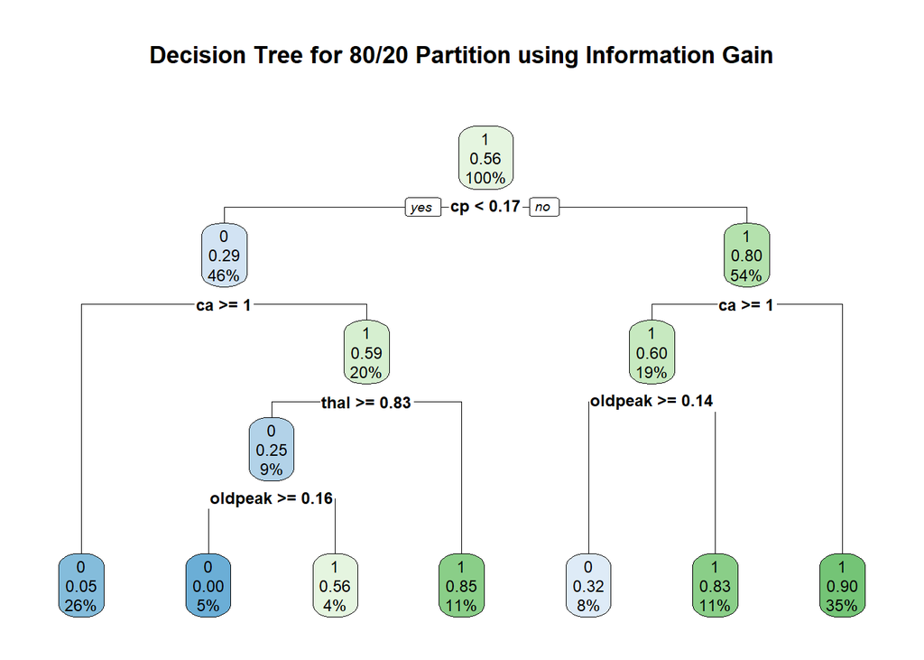

```r
rpart.plot(tree_1_ig, main = "Decision Tree for 80/20 Partition using Information Gain")
```

This s a decision tree diagram for a 80/20 partition using information gain.The result shows that Chest pain type (cp) had the highest information gain value so it was represented in first level (root).The tree contains 4 variables with 6 splits. Splits have occurred on the variables Cp, Ca ,thal, and oldpeak.

```r
#predict the species on the test set
pred_1_ig <- predict(tree_1_ig, newdata = test_data, type = "class")

#create a confusion matrix
table(pred_1_ig, test_data$target)
```

```
##
## pred_1_ig  0  1
##         0 17  4
##         1  9 27
```

```r
pred <- as.factor(pred_1_ig)
actual <- as.factor(test_data$target)

confusionMatrix(pred, actual)
```

```
## Confusion Matrix and Statistics
##
##           Reference
## Prediction  0  1
##          0 17  4
##          1  9 27
##
##                Accuracy : 0.7719
##                  95% CI : (0.6416, 0.8726)
##     No Information Rate : 0.5439
##     P-Value [Acc > NIR] : 0.0003105
##
##                   Kappa : 0.5331
##
##  Mcnemar's Test P-Value : 0.2672575
##
##             Sensitivity : 0.6538
##             Specificity : 0.8710
##          Pos Pred Value : 0.8095
##          Neg Pred Value : 0.7500
##              Prevalence : 0.4561
##          Detection Rate : 0.2982
##    Detection Prevalence : 0.3684
##       Balanced Accuracy : 0.7624
##
##        'Positive' Class : 0
##
```

```r
#calculate the overall accuracy
mean(pred_1_ig ==  test_data$target)
```

```
## [1] 0.7719298
```

```r
# Manually calculate precision
precision <- 17 / (17 + 4)

# Print precision
print(paste("Precision:", precision))
```

```
## [1] "Precision: 0.80952380952381"
```

| Evaluation Method | Value |
| --- | --- |
| Accuracy | 77.1% |
| Precision | 80.9% |
| Sensitivity | 65.3% |
| Specificity | 87% |

## plot the decision trees for each measure(GINI index)

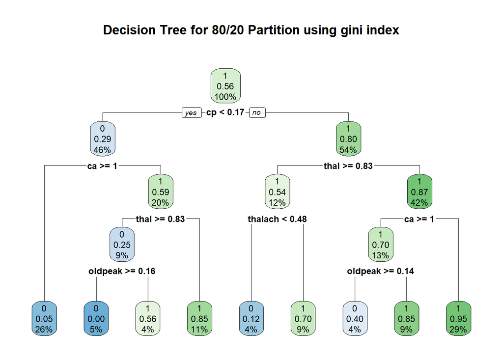

```r
rpart.plot(tree_1_gini, main = "Decision Tree for 80/20 Partition using gini index")
```

his s a decision tree diagram for a 80/20partition using Gini index .The result shows that Chest pain type (cp) had the highest ΔGini value so it was represented in first level (root).The tree contains 5 variables with 8 splits. Splits have occurred on the variables Cp, Ca ,thalach, thal,and oldpeak.

```r
#predict the target on the test set
tree_1_gini <- predict(tree_1_gini, newdata = test_data, type = "class")

#create a confusion matrix
table(tree_1_gini, test_data$target)
```

```
##
## tree_1_gini  0  1
##           0 16  4
##           1 10 27
```

```r
pred <- as.factor(tree_1_gini)
actual <- as.factor(test_data$target)

confusionMatrix(pred, actual)
```

```
## Confusion Matrix and Statistics
##
##           Reference
## Prediction  0  1
##          0 16  4
##          1 10 27
##
##                Accuracy : 0.7544
##                  95% CI : (0.6224, 0.8587)
##     No Information Rate : 0.5439
##     P-Value [Acc > NIR] : 0.0008594
##
##                   Kappa : 0.4956
##
##  Mcnemar's Test P-Value : 0.1814492
##
##             Sensitivity : 0.6154
##             Specificity : 0.8710
##          Pos Pred Value : 0.8000
##          Neg Pred Value : 0.7297
##              Prevalence : 0.4561
##          Detection Rate : 0.2807
##    Detection Prevalence : 0.3509
##       Balanced Accuracy : 0.7432
##
##        'Positive' Class : 0
##
```

```r
#calculate the overall accuracy
mean(tree_1_gini ==  test_data$target)
```

```
## [1] 0.754386
```

```r
# Manually calculate precision
precision <- 16 / (16 + 4)

# Print precision
print(paste("Precision:", precision))
```

```
## [1] "Precision: 0.8"
```

| Evaluation Method | Value |
| --- | --- |
| Accuracy | 75.4% |
| Precision | 80% |
| Sensitivity | 61.5% |
| Specificity | 87% |

##plot the decision trees for each measure(GINI ratio)

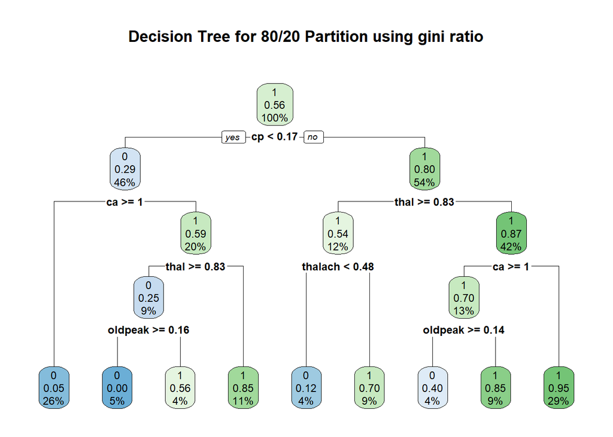

```r
rpart.plot(tree_1_gr, main = "Decision Tree for 80/20 Partition using gini ratio")
```

This s a decision tree diagram for a 80/20 partition using Gini ratio .The result shows that Chest pain type (cp) had the highest Gini ratio value so it was represented in first level (root).The tree contains 5 variables with 8 splits. Splits have occurred on the variables Cp, Ca ,thalach, thal,and oldpeak.

```r
#predict the target on the test set
tree_1_gr <- predict(tree_1_gr, newdata = test_data, type = "class")

#create a confusion matrix
table(tree_1_gr, test_data$target)
```

```
##
## tree_1_gr  0  1
##         0 16  4
##         1 10 27
```

```r
pred <- as.factor(tree_1_gr)
actual <- as.factor(test_data$target)

confusionMatrix(pred, actual)
```

```
## Confusion Matrix and Statistics
##
##           Reference
## Prediction  0  1
##          0 16  4
##          1 10 27
##
##                Accuracy : 0.7544
##                  95% CI : (0.6224, 0.8587)
##     No Information Rate : 0.5439
##     P-Value [Acc > NIR] : 0.0008594
##
##                   Kappa : 0.4956
##
##  Mcnemar's Test P-Value : 0.1814492
##
##             Sensitivity : 0.6154
##             Specificity : 0.8710
##          Pos Pred Value : 0.8000
##          Neg Pred Value : 0.7297
##              Prevalence : 0.4561
##          Detection Rate : 0.2807
##    Detection Prevalence : 0.3509
##       Balanced Accuracy : 0.7432
##
##        'Positive' Class : 0
##
```

```r
#calculate the overall accuracy
mean(tree_1_gr ==  test_data$target)
```

```
## [1] 0.754386
```

```r
# Manually calculate precision
precision <- 16 / (16 + 4)

# Print precision
print(paste("Precision:", precision))
```

```
## [1] "Precision: 0.8"
```

| Evaluation Method | Value |
| --- | --- |
| Accuracy | 75.4% |
| Precision | 80% |
| Sensitivity | 61.5% |
| Specificity | 87% |

the confusion matrix of the IG model showed the accuracy of 77%, th gini ratio showed 75.4%, while the gini index showed 75.4% accuracy looking at the accuracy level we can see that IG model performed better.

## C4.5 algorithm (80/20)

```r
library(RWeka)
# load the package
library(RWeka)
# load data
# fit model
tree <- J48(as.factor(target) ~ ., data = train_data)
# summarize the fit
summary(tree)
```

```
##
## === Summary ===
##
## Correctly Classified Instances         204               93.1507 %
## Incorrectly Classified Instances        15                6.8493 %
## Kappa statistic                          0.8594
## Mean absolute error                      0.1192
## Root mean squared error                  0.2441
## Relative absolute error                 24.254  %
## Root relative squared error             49.2523 %
## Total Number of Instances              219
##
## === Confusion Matrix ===
##
##    a   b   <-- classified as
##   84  11 |   a = 0
##    4 120 |   b = 1
```

```r
# make predictions
predictions <- predict(tree, test_data)
# summarize accuracy
table(predictions, test_data$target)
```

```
##
## predictions  0  1
##           0 19  5
##           1  7 26
```

```r
#calculate the overall accuracy
mean(predictions ==  test_data$target)
```

```
## [1] 0.7894737
```

```r
library(partykit)
```

```r
# load the package
library(ipred)
# fit model
tree <- Bagging (as.factor(target) ~ ., data = train_data)
summary(tree)
```

```
##
## === Summary ===
##
## Correctly Classified Instances         198               90.411  %
## Incorrectly Classified Instances        21                9.589  %
## Kappa statistic                          0.8031
## Mean absolute error                      0.2264
## Root mean squared error                  0.2877
## Relative absolute error                 46.0852 %
## Root relative squared error             58.0554 %
## Total Number of Instances              219
##
## === Confusion Matrix ===
##
##    a   b   <-- classified as
##   81  14 |   a = 0
##    7 117 |   b = 1
```

```r
# make predictions
predictions <- predict(tree, test_data)
# summarize accuracy
table(predictions, test_data$target)
```

```
##
## predictions  0  1
##           0 20  3
##           1  6 28
```

```r
#calculate the overall accuracy
mean(predictions ==  test_data$target)
```

```
## [1] 0.8421053
```

## split the data in training and test data (60/40)

```r
set.seed(123)
data_split <- initial_split(dataset, prop = 0.60)
train_data <- training(data_split)
test_data <- testing(data_split)
```

## build decision tree for each partition and measure

```r
tree_1_ig <- rpart(target ~ ., data = train_data, method = "class", parms = list(split = "information"))

tree_1_gini <- rpart(target ~ ., data = train_data, method = "class", parms = list(split = "gini"))

tree_1_gr <- rpart(target ~ ., data = train_data, method = "class", parms = list(split = "anova"))
```

##plot the decision trees for each measure(IG)

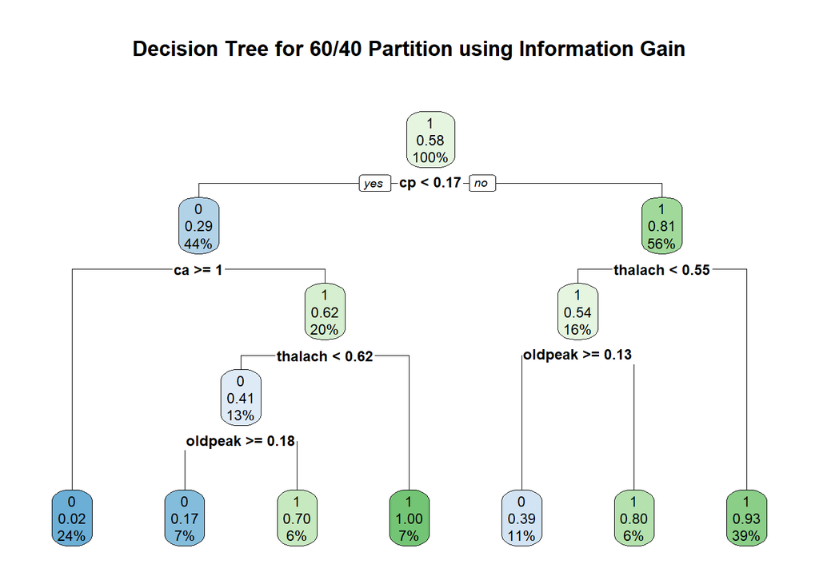

```r
rpart.plot(tree_1_ig, main = "Decision Tree for 60/40 Partition using Information Gain")
```

This is a decision tree diagram for a 60/40 partition using information gain.The result shows that Chest pain type (cp) had the highest information gain value so it was represented in first level (root).The tree contains 4 variables with 6 splits. Splits have occurred on the variables Cp, Ca ,thalach and oldpeak.

```r
#predict the target on the test set
pred_1_ig <- predict(tree_1_ig, newdata = test_data, type = "class")

#create a confusion matrix
table(pred_1_ig, test_data$target)
```

```
##
## pred_1_ig  0  1
##         0 37 13
##         1 17 47
```

```r
pred <- as.factor(pred_1_ig)
actual <- as.factor(test_data$target)

confusionMatrix(pred, actual)
```

```
## Confusion Matrix and Statistics
##
##           Reference
## Prediction  0  1
##          0 37 13
##          1 17 47
##
##                Accuracy : 0.7368
##                  95% CI : (0.6461, 0.8149)
##     No Information Rate : 0.5263
##     P-Value [Acc > NIR] : 3.309e-06
##
##                   Kappa : 0.4703
##
##  Mcnemar's Test P-Value : 0.5839
##
##             Sensitivity : 0.6852
##             Specificity : 0.7833
##          Pos Pred Value : 0.7400
##          Neg Pred Value : 0.7344
##              Prevalence : 0.4737
##          Detection Rate : 0.3246
##    Detection Prevalence : 0.4386
##       Balanced Accuracy : 0.7343
##
##        'Positive' Class : 0
##
```

```r
#calculate the overall accuracy
mean(pred_1_ig ==  test_data$target)
```

```
## [1] 0.7368421
```

```r
# Manually calculate precision
precision <- 37/ (37+ 13)

# Print precision
print(paste("Precision:", precision))
```

```
## [1] "Precision: 0.74"
```

| Evaluation Method | Value |
| --- | --- |
| Accuracy | 73.6% |
| Precision | 74% |
| Sensitivity | 68.5% |
| Specificity | 78.3% |

## plot the decision trees for each measure(GINI index)

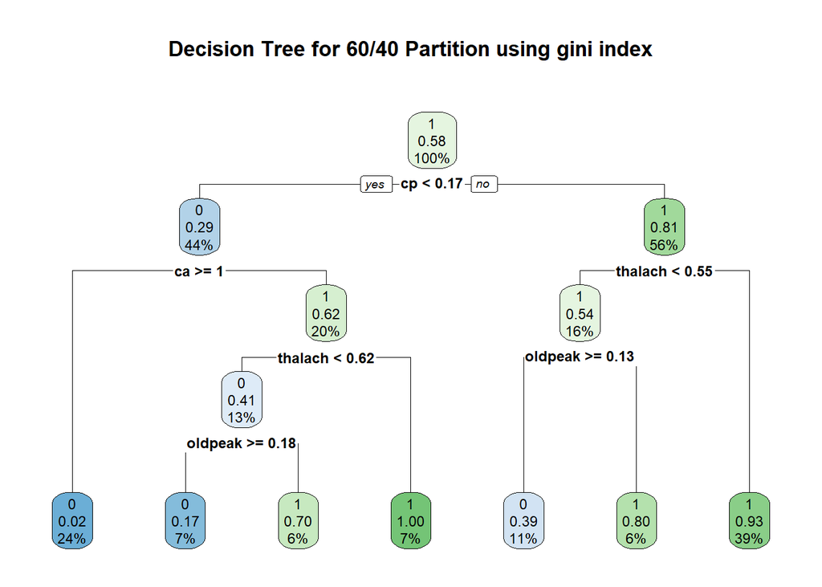

```r
rpart.plot(tree_1_gini, main = "Decision Tree for 60/40 Partition using gini index")
```

```r
#predict the target on the test set
tree_1_gini <- predict(tree_1_gini, newdata = test_data, type = "class")

#create a confusion matrix
table(tree_1_gini, test_data$target)
```

```
##
## tree_1_gini  0  1
##           0 37 13
##           1 17 47
```

```r
pred <- as.factor(tree_1_gini)
actual <- as.factor(test_data$target)

confusionMatrix(pred, actual)
```

```
## Confusion Matrix and Statistics
##
##           Reference
## Prediction  0  1
##          0 37 13
##          1 17 47
##
##                Accuracy : 0.7368
##                  95% CI : (0.6461, 0.8149)
##     No Information Rate : 0.5263
##     P-Value [Acc > NIR] : 3.309e-06
##
##                   Kappa : 0.4703
##
##  Mcnemar's Test P-Value : 0.5839
##
##             Sensitivity : 0.6852
##             Specificity : 0.7833
##          Pos Pred Value : 0.7400
##          Neg Pred Value : 0.7344
##              Prevalence : 0.4737
##          Detection Rate : 0.3246
##    Detection Prevalence : 0.4386
##       Balanced Accuracy : 0.7343
##
##        'Positive' Class : 0
##
```

```r
#calculate the overall accuracy
mean(tree_1_gini ==  test_data$target)
```

```
## [1] 0.7368421
```

```r
# Manually calculate precision
precision <- 37/ (37+ 13)

# Print precision
print(paste("Precision:", precision))
```

```
## [1] "Precision: 0.74"
```

| Evaluation Method | Value |
| --- | --- |
| Accuracy | 73.6% |
| Precision | 74% |
| Sensitivity | 68.5% |
| Specificity | 78.3% |

## plot the decision trees for each measure(GINI ratio)

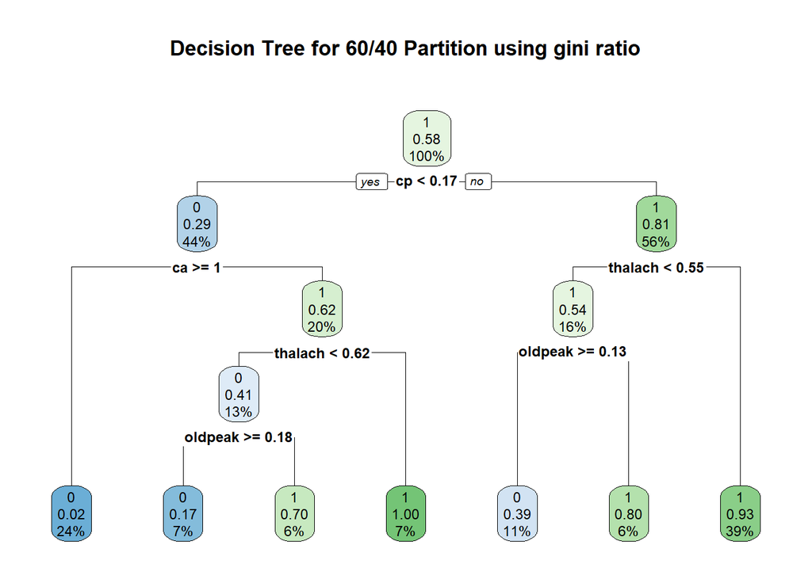

```r
rpart.plot(tree_1_gr, main = "Decision Tree for 60/40 Partition using gini ratio")
```

This is a decision tree diagram for a 60/40 partition using Gini ratio .The result shows that Chest pain type (cp) had the highest Gini ratio value so it was represented in first level (root).The tree contains 4 variables with 6 splits. Splits have occurred on the variables Cp, Ca ,thalach and oldpeak.

## predict the model on the test set

```r
#predict the target on the test set
tree_1_gr <- predict(tree_1_ig, newdata = test_data, type = "class")

#create a confusion matrix
table(tree_1_gr, test_data$target)
```

```
##
## tree_1_gr  0  1
##         0 37 13
##         1 17 47
```

```r
pred <- as.factor(tree_1_gr)
actual <- as.factor(test_data$target)
confusionMatrix(pred, actual)
```

```
## Confusion Matrix and Statistics
##
##           Reference
## Prediction  0  1
##          0 37 13
##          1 17 47
##
##                Accuracy : 0.7368
##                  95% CI : (0.6461, 0.8149)
##     No Information Rate : 0.5263
##     P-Value [Acc > NIR] : 3.309e-06
##
##                   Kappa : 0.4703
##
##  Mcnemar's Test P-Value : 0.5839
##
##             Sensitivity : 0.6852
##             Specificity : 0.7833
##          Pos Pred Value : 0.7400
##          Neg Pred Value : 0.7344
##              Prevalence : 0.4737
##          Detection Rate : 0.3246
##    Detection Prevalence : 0.4386
##       Balanced Accuracy : 0.7343
##
##        'Positive' Class : 0
##
```

```r
#calculate the overall accuracy
mean(tree_1_gr ==  test_data$target)
```

```
## [1] 0.7368421
```

```r
# Manually calculate precision
precision <- 37/ (37+13)

# Print precision
print(paste("Precision:", precision))
```

```
## [1] "Precision: 0.74"
```

| Evaluation Method | Value |
| --- | --- |
| Accuracy | 73.6% |
| Precision | 74% |
| Sensitivity | 68.5% |
| Specificity | 78.3% |

## C4.5 algorithm (60/40)

```r
library(RWeka)
# load the package
library(RWeka)
# load data
# fit model
tree <- J48(as.factor(target) ~ ., data = train_data)
# summarize the fit
summary(tree)
```

```
##
## === Summary ===
##
## Correctly Classified Instances         153               93.865  %
## Incorrectly Classified Instances        10                6.135  %
## Kappa statistic                          0.8739
## Mean absolute error                      0.1003
## Root mean squared error                  0.224
## Relative absolute error                 20.7166 %
## Root relative squared error             45.5244 %
## Total Number of Instances              163
##
## === Confusion Matrix ===
##
##   a  b   <-- classified as
##  63  4 |  a = 0
##   6 90 |  b = 1
```

```r
# make predictions
predictions <- predict(tree, test_data)
# summarize accuracy
table(predictions, test_data$target)
```

```
##
## predictions  0  1
##           0 39 10
##           1 15 50
```

```r
#calculate the overall accuracy
mean(predictions ==  test_data$target)
```

```
## [1] 0.7807018
```

[figure not shown]

```r
library(partykit)
plot(tree)
```

```r
# load the package
library(ipred)
# fit model
tree <- Bagging (as.factor(target) ~ ., data = train_data)
summary(tree)
```

```
##
## === Summary ===
##
## Correctly Classified Instances         148               90.7975 %
## Incorrectly Classified Instances        15                9.2025 %
## Kappa statistic                          0.8069
## Mean absolute error                      0.1919
## Root mean squared error                  0.2597
## Relative absolute error                 39.6122 %
## Root relative squared error             52.7905 %
## Total Number of Instances              163
##
## === Confusion Matrix ===
##
##   a  b   <-- classified as
##  56 11 |  a = 0
##   4 92 |  b = 1
```

```r
# make predictions
predictions <- predict(tree, test_data)
# summarize accuracy
table(predictions, test_data$target)
```

```
##
## predictions  0  1
##           0 36  9
##           1 18 51
```

```r
#calculate the overall accuracy
mean(predictions ==  test_data$target)
```

```
## [1] 0.7631579
```

| **Evaluation and Comparison in classification:** |
| --- |

We applied several methods to evaluate classification models which are: accuracy, sensitivity , specificity, and precision. Accuracy means the ability of the model to classify the data correctly. It’s used to evaluate the performance of the model based on the test data. Sensitivity means the ability of the model to correctly identify positive tuples. Specificity is the opposite of the sensitivity. It means the ability of the model to correctly identify negative tuples. Finally, precision means the proportion of correctly predicted positive tuples out of all tuples predictive as positive.

Information Gain: It measures the amount of information provided by a feature, information gain is used to determine the best feature which has the highest value to split the data at each node of the tree.

Gini index: It is a measurement used in classifying the data and building decision trees, it is used to determine the splitting attribute. The gini index measure the impurity of the data and the attribute with the lowest gini index value will have the highest reduction impurity and will be chosen as the split attribute.

Gain ratio: It is a measure used in decision tree algorithms to select the best feature that has the highest value for splitting data. It takes into consideration both the information gain and the split information of a feature.

**75% Training, 25% Testing :**

|  | IG | IG Ratio | Gini Index |
| --- | --- | --- | --- |
| **Accuracy** | 80% | 84.5% | 84.5% |
| **Precision** | 81.4% | 85.7% | 85.7% |
| **Sensitivity** | 70.9% | 77.4% | 77.4% |
| **Specificity** | 87.5% | 90% | 90% |

**80% Training, 20% Testing :**

|  | IG | IG Ratio | Gini Index |
| --- | --- | --- | --- |
| **Accuracy** | 77% | 75.4% | 75.4% |
| **Precision** | 80.9% | 80% | 80% |
| **Sensitivity** | 65% | 61.5% | 61.5% |
| **Specificity** | 87% | 87% | 87% |

**60% Training, 40% Testing :**

|  | IG | IG Ratio | Gini Index |
| --- | --- | --- | --- |
| **Accuracy** | 73.6% | 73.6% | 73.6% |
| **Precision** | 74% | 74% | 74% |
| **Sensitivity** | 68.5% | 68.5% | 68.5% |
| **Specificity** | 78.3% | 78.3% | 78.3% |

## **Summary for 75% training set and 25% testing set:**

The best algorithm based on accuracy, precision, sensitivity, and specificity is Gini index and Information Gain Ratio (IG ratio) with an accuracy of 84.5%

## **Summary for 80% training set and 20% testing set:**

The best algorithm based on accuracy, precision, sensitivity, and specificity is Information Gain (IG) with an accuracy of 77%

## **Summary for 60% training set and 40% testing set:**

All algorithms perform equally with an accuracy of 73.6%.

[output not shown]

## **Finding in classification:**

The decision tree illustrates that 5 attributes were used in predicting the class label which are ( cp ,cab,thal ,thalach and oldpeak ) where the other attributes had no effect in the class label prediction.

| Evaluation and Comparison in clustering: |
| --- |

[output not shown]

| Finding in clustring: |
| --- |

Both approaches (Classification and Clustering)were helpful for building models for our data set that can help in reaching our goal which is detecting people from heart attacks, but since our data set includes class label which is target, classification was considered the best option to predict the possibilities of having heart attack based on the attributes also the model had great accuracy.

| Refrences: |
| --- |

[1]“rstudio - ggplot2 library installation in R Studio,” Stack Overflow. https://stackoverflow.com/questions/36582347/ggplot2-library-installation-in-r-studio. [2]“boxplot function - RDocumentation,” www.rdocumentation.org. https://www.rdocumentation.org/packages/graphics/versions/3.6.2/topics/boxplot. [3]“R Documentation and manuals | R Documentation,” Rdocumentation.org, 2019. https://www.rdocumentation.org/.